# Categorical data with brms

Peter Ralph

19 January 2021 – Advanced Biological Statistics

# Categorical data

## Hair and Eye color

```r
data(HairEyeColor)
```

```
HairEyeColor             package:datasets              R Documentation

Hair and Eye Color of Statistics Students

Description:

     Distribution of hair and eye color and sex in 592 statistics
     students.

Usage:

     HairEyeColor

Format:

     A 3-dimensional array resulting from cross-tabulating 592
     observations on 3 variables.  The variables and their levels are
     as follows:

       No  Name  Levels
        1  Hair  Black, Brown, Red, Blond
        2  Eye   Brown, Blue, Hazel, Green
        3  Sex   Male, Female

Details:

     The Hair x Eye table comes from a survey of students at the
     University of Delaware reported by Snee (1974).  The split by
     ‘Sex’ was added by Friendly (1992a) for didactic purposes.

     This data set is useful for illustrating various techniques for
     the analysis of contingency tables, such as the standard
     chi-squared test or, more generally, log-linear modelling, and
     graphical methods such as mosaic plots, sieve diagrams or
     association plots.

Source:

     <URL:
     http://euclid.psych.yorku.ca/ftp/sas/vcd/catdata/haireye.sas>

     Snee (1974) gives the two-way table aggregated over ‘Sex’.  The
     ‘Sex’ split of the ‘Brown hair, Brown eye’ cell was changed to
     agree with that used by Friendly (2000).

References:

     Snee, R. D. (1974).  Graphical display of two-way contingency
     tables.  _The American Statistician_, *28*, 9-12.  doi:
     10.2307/2683520 (URL: http://doi.org/10.2307/2683520).
```

```
## , , Sex = Male
##
##        Eye
## Hair    Brown Blue Hazel Green
##   Black    32   11    10     3
##   Brown    53   50    25    15
##   Red      10   10     7     7
##   Blond     3   30     5     8
##
## , , Sex = Female
##
##        Eye
## Hair    Brown Blue Hazel Green
##   Black    36    9     5     2
##   Brown    66   34    29    14
##   Red      16    7     7     7
##   Blond     4   64     5     8
```

```r
haireye <- as.data.frame(HairEyeColor)
names(haireye) <- tolower(names(haireye))
names(haireye)[names(haireye) == "freq"] <- "number"
haireye
```

```
##     hair   eye    sex number
## 1  Black Brown   Male     32
## 2  Brown Brown   Male     53
## 3    Red Brown   Male     10
## 4  Blond Brown   Male      3
## 5  Black  Blue   Male     11
## 6  Brown  Blue   Male     50
## 7    Red  Blue   Male     10
## 8  Blond  Blue   Male     30
## 9  Black Hazel   Male     10
## 10 Brown Hazel   Male     25
## 11   Red Hazel   Male      7
## 12 Blond Hazel   Male      5
## 13 Black Green   Male      3
## 14 Brown Green   Male     15
```

[output cut: 18 more lines]

*Questions:*

1. Are hair and eye color independent in this sample?
2. Do hair and eye color proportions differ by gender?

# Poisson models for count data

We have for data
$$\begin{aligned}
n_{ij} = \text{( number of observations in categories $i$ and $j$ )} .
\end{aligned}$$
and
$$\begin{aligned}
n_{i \cdot} &= \text{( total number of observations in category $i$ )} , \\
n_{\cdot j} &= \text{( total number of observations in category $j$ )} , \\
n_{\cdot \cdot} &= \text{( total number of observations )} .
\end{aligned}$$

*Question:* Is $n_{i \cdot}$ fixed? What about $n_{\cdot j}$? Or $n_{\cdot \cdot}$?

*Answer:* Happily, it will turn out not to matter (for the model).

## Poisson additivity

If we have Poisson-many things of two categories:
$$\begin{aligned}
A &\sim \Poisson(a) \\
B &\sim \Poisson(b)
\end{aligned}$$
then the total number of things is also Poisson:
$$A + B \sim \Poisson(a + b)$$
and each thing chooses its type independently:
$$A \given A + B \sim \Binom\left(A+B, \frac{a}{a+b}\right) .$$

## Poisson models for contingency tables

So, if we fit a model where

$$\begin{aligned}
n_{ij}
&\sim \Poisson(\lambda_{ij})
\end{aligned}$$

then
$$\begin{aligned}
\frac{\lambda_{ij}}{\sum_{k\ell} \lambda_{k\ell}}
&=
(\text{proportion in category $ij$}) \\
\frac{\lambda_{ij}}{\sum_{k} \lambda_{kj}}
&=
(\text{proportion of row $j$ in column $i$}) \\
\frac{\lambda_{ij}}{\lambda_{ij} + \lambda_{k\ell}}
&=
(\text{proportion of those in $k\ell$ or $ij$ that are $ij$})
\end{aligned}$$

For example, the *proportion of black-haired people who have blue eyes* is
$$\begin{aligned}
& \P\left(\text{ eye blue } \given \text{ hair black } \right) \\
&\qquad =
\frac{
\lambda_{\text{blue},\text{black}}
}{
\lambda_{\cdot,\text{black}}
} \\
&\qquad =
\frac{
\lambda_{\text{blue},\text{black}}
}{
\lambda_{\text{brown},\text{black}}
+ \lambda_{\text{blue},\text{black}}
+ \lambda_{\text{hazel},\text{black}}
+ \lambda_{\text{green},\text{black}}
}
\end{aligned}$$

*Question:* What’s
$$\begin{aligned}
\P\left(\text{ male } \given \text{ hair black } \right) = ?
\end{aligned}$$

## Independence and multiplicativity

If hair and eye color are *independent*, then probabilities of combinations are *multiplicative*:

$$\begin{aligned}
&\P\{\text{black hair and blue eyes}\} \\
&\qquad =
\P\{\text{black hair}\} \times \P\{\text{blue eyes}\given\text{black hair}\} \\
\end{aligned}$$

which if independent is
$$\begin{aligned}
&\hphantom{\P\{\text{black hair and blue eyes}\}} \\
&\qquad =
\P\{\text{black hair}\} \times \P\{\text{blue eyes}\}
\end{aligned}$$

In shorthand,
$$\begin{aligned}
p_{ij} = p_i \times p_j .
\end{aligned}$$

## Additivity and independence

If we use a *log link function*, additivity corresponds to independence:
$$\begin{aligned}
p_{ij}
&=
\frac{
\lambda_{ij}
}{
\sum_{ab} \lambda_{ab}
} \\
&=
\frac{
e^{\beta_i + \gamma_j}
}{
\sum_{ab} e^{\beta_a + \gamma_b}
} \\
&=
\left(
\frac{
e^{\beta_i}
}{
\sum_{a} e^{\beta_a}
}
\right)
\times
\left(
\frac{
e^{\gamma_j}
}{
\sum_{b} e^{\gamma_b}
}
\right) \\
&= p_i \times p_j
\end{aligned}$$

# hair and eye colors, with brms

## brms

```r
he_formula <- brmsformula(number ~ sex + hair * eye + (hair + eye) * sex)
```

## Flat priors

```r
get_prior(he_formula, data=haireye, family='poisson')
```

```
##                   prior     class                coef group resp dpar nlpar bound       source
##                  (flat)         b                                                      default
##                  (flat)         b             eyeBlue                             (vectorized)
##                  (flat)         b            eyeGreen                             (vectorized)
##                  (flat)         b            eyeHazel                             (vectorized)
##                  (flat)         b           hairBlond                             (vectorized)
##                  (flat)         b   hairBlond:eyeBlue                             (vectorized)
##                  (flat)         b  hairBlond:eyeGreen                             (vectorized)
##                  (flat)         b  hairBlond:eyeHazel                             (vectorized)
##                  (flat)         b           hairBrown                             (vectorized)
##                  (flat)         b   hairBrown:eyeBlue                             (vectorized)
##                  (flat)         b  hairBrown:eyeGreen                             (vectorized)
##                  (flat)         b  hairBrown:eyeHazel                             (vectorized)
##                  (flat)         b             hairRed                             (vectorized)
##                  (flat)         b     hairRed:eyeBlue                             (vectorized)
##                  (flat)         b    hairRed:eyeGreen                             (vectorized)
##                  (flat)         b    hairRed:eyeHazel                             (vectorized)
##                  (flat)         b           sexFemale                             (vectorized)
##                  (flat)         b   sexFemale:eyeBlue                             (vectorized)
##                  (flat)         b  sexFemale:eyeGreen                             (vectorized)
##                  (flat)         b  sexFemale:eyeHazel                             (vectorized)
##                  (flat)         b sexFemale:hairBlond                             (vectorized)
##                  (flat)         b sexFemale:hairBrown                             (vectorized)
##                  (flat)         b   sexFemale:hairRed                             (vectorized)
##  student_t(3, 2.3, 2.5) Intercept                                                      default
```

```r
he_priors <- c(prior('normal(0,3)', class='b'))
```

```r
he_fit <- brm(he_formula,
              data=haireye,
              family=poisson(link='log'),
              prior=he_priors)
summary(he_fit)
```

```
##  Family: poisson
##   Links: mu = log
## Formula: number ~ sex + hair * eye + (hair + eye) * sex
##    Data: haireye (Number of observations: 32)
## Samples: 4 chains, each with iter = 2000; warmup = 1000; thin = 1;
##          total post-warmup samples = 4000
##
## Population-Level Effects:
##                     Estimate Est.Error l-95% CI u-95% CI Rhat Bulk_ESS Tail_ESS
## Intercept               3.43      0.16     3.10     3.74 1.00     2530     2801
## sexFemale               0.09      0.21    -0.31     0.50 1.00     2835     3128
## hairBrown               0.53      0.19     0.16     0.91 1.00     2523     2640
## hairRed                -1.05      0.29    -1.62    -0.50 1.00     2589     2746
## hairBlond              -2.66      0.41    -3.49    -1.89 1.00     2562     2667
## eyeBlue                -0.97      0.27    -1.49    -0.45 1.00     2907     2882
## eyeHazel               -1.31      0.31    -1.94    -0.73 1.00     2949     2919
## eyeGreen               -2.27      0.44    -3.18    -1.48 1.00     2402     2466
## hairBrown:eyeBlue       0.83      0.28     0.28     1.40 1.00     2689     2600
## hairRed:eyeBlue         0.73      0.40    -0.08     1.51 1.00     3026     2953
## hairBlond:eyeBlue       3.73      0.44     2.92     4.64 1.00     2548     2240
## hairBrown:eyeHazel      0.67      0.33     0.05     1.33 1.00     2990     3269
## hairRed:eyeHazel        0.82      0.43    -0.02     1.69 1.00     3314     3239
## hairBlond:eyeHazel      1.70      0.56     0.64     2.81 1.00     2937     2369
## hairBrown:eyeGreen      1.07      0.46     0.21     2.04 1.00     2467     2804
## hairRed:eyeGreen        1.84      0.54     0.80     2.91 1.00     2557     2597
## hairBlond:eyeGreen      3.24      0.59     2.12     4.45 1.00     2282     2773
## sexFemale:hairBrown     0.13      0.23    -0.31     0.59 1.00     2512     2906
## sexFemale:hairRed       0.24      0.31    -0.37     0.83 1.00     2658     2739
## sexFemale:hairBlond     0.86      0.30     0.27     1.44 1.00     2547     2683
## sexFemale:eyeBlue      -0.41      0.22    -0.85     0.03 1.00     3983     3291
## sexFemale:eyeHazel     -0.32      0.25    -0.82     0.16 1.00     4442     3327
## sexFemale:eyeGreen     -0.48      0.29    -1.06     0.09 1.00     4119     3035
##
## Samples were drawn using sampling(NUTS). For each parameter, Bulk_ESS
## and Tail_ESS are effective sample size measures, and Rhat is the potential
## scale reduction factor on split chains (at convergence, Rhat = 1).
```

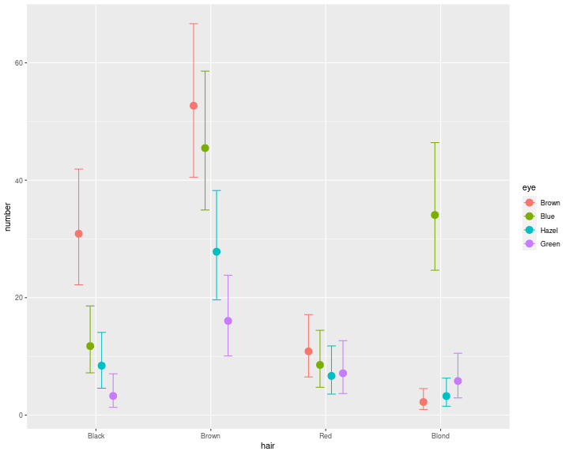

```r
conditional_effects(he_fit, effects="hair:eye")
```

But, that was *numbers*: here’s the credible intervals for the proportions of each eye color for each hair color:

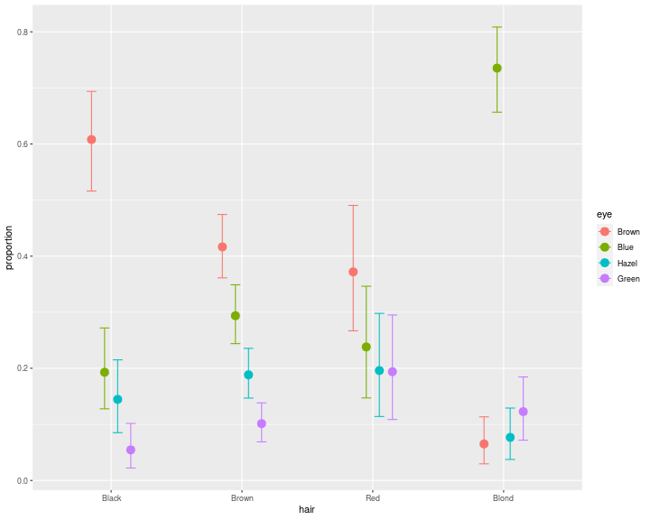

Recall the “reference” levels are hair = Black and eye = Brown

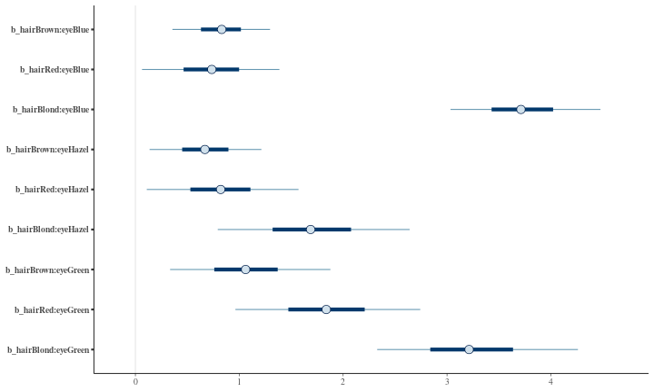

# Back to the questions

*Questions:*

1. Are hair and eye color independent in this sample?
2. Do hair and eye color proportions differ by gender?

## *Are hair and eye color independent in this sample?*

(What do we mean: given gender? averaged across gender?)

Recall the “reference” levels are hair = Black and eye = Brown

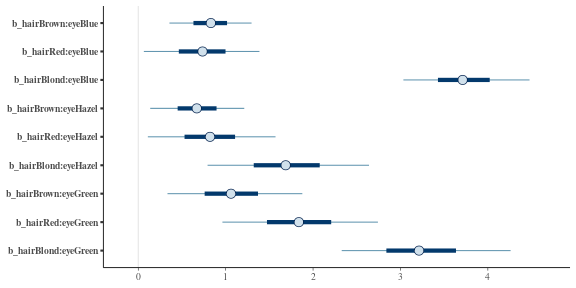

Eye color proportions by hair type:

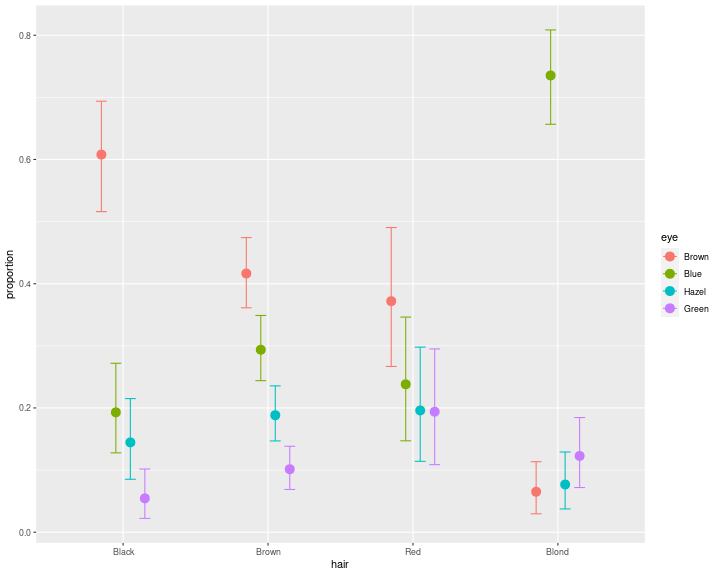

Hair color proportions by eye type:

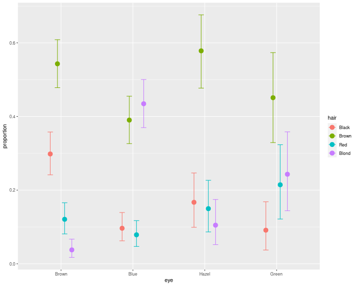

## *Do hair and eye color proportions differ by gender?*

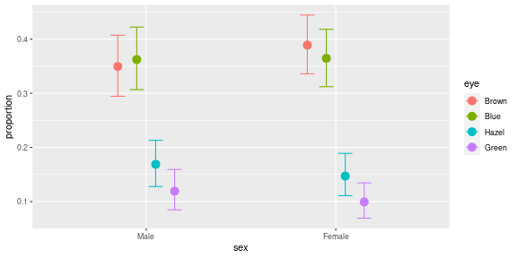

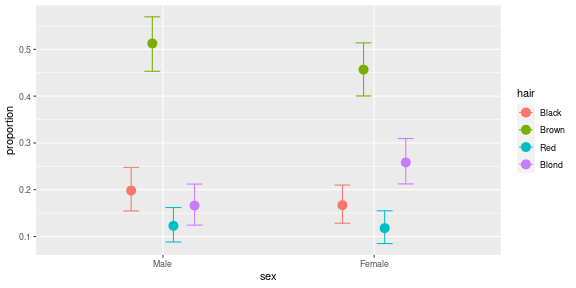

# Testing our method

*Question:* What would we have seen if hair and eye color *were* independent?

## Testing

Let’s simulate some test data, under independence.

```r
sim_data <- function () {
    n <- sum(haireye$number)
    p_hair <- tapply(haireye$number, haireye$hair, sum) / n
    p_eye <- tapply(haireye$number, haireye$eye, sum) / n
    p_sex <- tapply(haireye$number, haireye$sex, sum) / n
    p <- (p_hair[haireye$hair] *
          p_eye[haireye$eye] *
          p_sex[haireye$sex])
    stopifnot(sum(p) == 1)
    number <- rmultinom(1, size=n, prob=p)
    return(number)
}
```

```r
sim_fits <- lapply(1:5, function (k) {
                       # replaces the data only locally
                       haireye$number <- sim_data()
                       update(he_fit, newdata=haireye) })
```

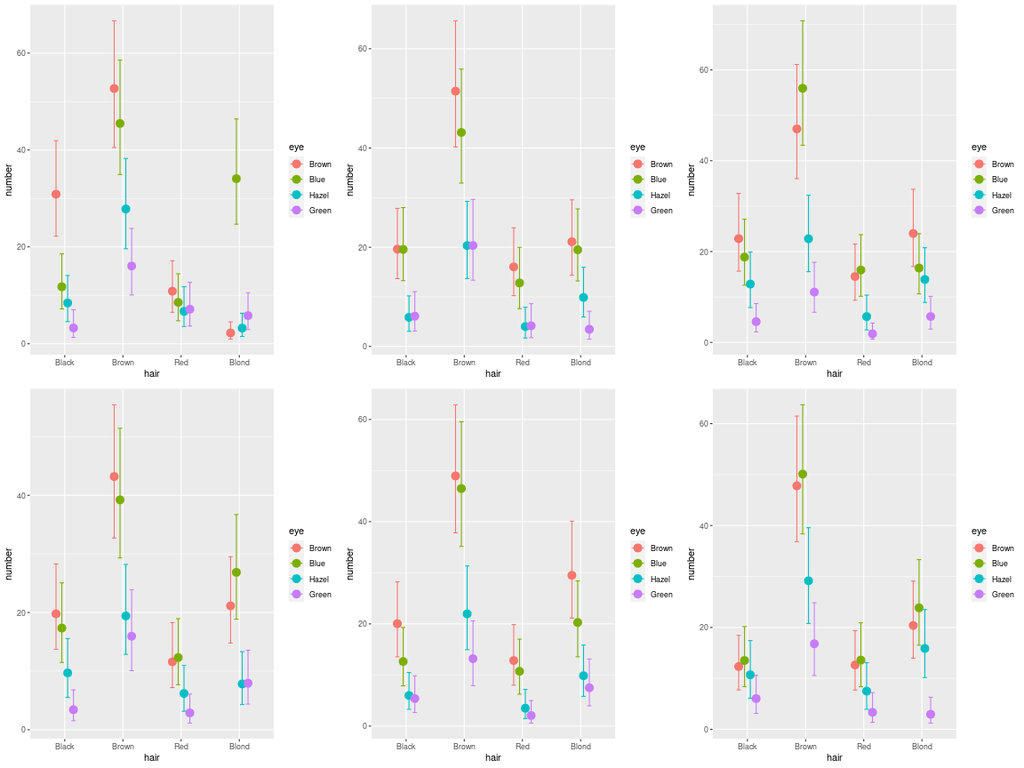

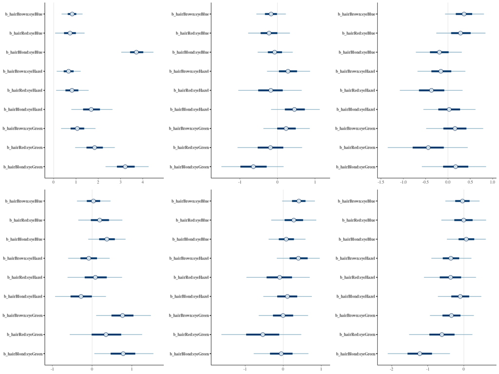